# TCRBroom: an example workflow

24 April 2023

# 1. Introduction

The `TCRBroom` package is designed to check pairwise overlap and cross-cohort overlap for TCR samples. This vignette shows a simple workflow illustrating how TCRBroom package works.

## Installation

Before the installation, please make sure you have installed JAGS-4.x.y.exe from http://www.sourceforge.net/projects/mcmc-jags/files.

The package can be installed using `devtools` by the following commands

```r
library(devtools)
install_github("rx-li/TCRBroom")
```

After the installation, the package can be loaded with

```r
library(TCRBroom)
```

# 2. Example workflow

## Plot pairwise and crosscohort overlaps

The TCR-seq data and meta table that we used in this example workflow can be found under the folder `data/`. 18 samples from 10 patients are simulated based on the real contaminated data.

First, we need to read the meta table, which documents sample names and their corresponding subject IDs.

```r
meta <- read.csv("../data/meta.csv")
# Please make sure that the column name are exactly "sample_name" and "subject_id".
colnames(meta) <- c("sample_name", "subject_id")
head(meta)
```

```
#>   sample_name subject_id
#> 1    s1_1.tsv        P01
#> 2    s1_2.tsv        P01
#> 3    s1_3.tsv        P01
#> 4    s1_4.tsv        P01
#> 5    s2_1.tsv        P02
#> 6    s2_2.tsv        P02
```

```r
dim(meta)
```

```
#> [1] 18  2
```

### Pairwise overlap

We can check the pairwise overlap between each two subjects using the following command.

```r
pairwise_table <- checkPairwise(meta, "../data/")
```

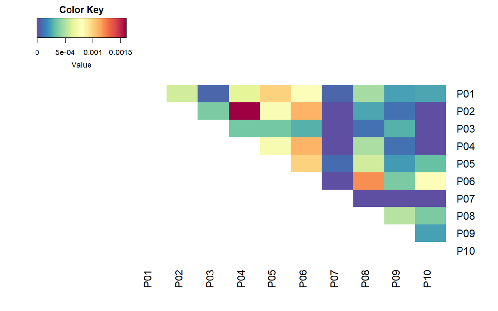

The heatmap shows the magnitude of the pairwise overlaps. A matrix is also created for users to check the values of the overlaps:

```r
pairwise_table[1:3, 1:3]
```

```
#>     P01     P02     P03
#> P01  NA 0.00058 7.1e-05
#> P02  NA      NA 3.7e-04
#> P03  NA      NA      NA
```

### Cross-cohort overlap

We can call the function `checkCrosscohort` to check the cross-cohort overlap (sequence prevalence).

```r
crosscohort_table <- checkCrosscohort(meta, "../data/", seq.n=30)
```

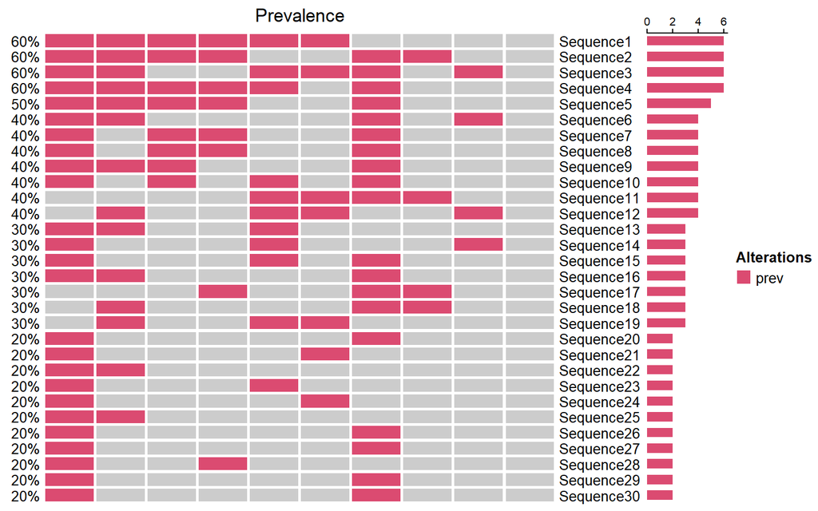

By default, the function will generate an heatmap showing prevalence for the 30 most prevalent sequences.

### Samples with few seqeunces identification

If users would like to identify the subjects with relatively fewer sequences (such as subjects with less than 3000 sequences), `ssampleIndicator` can generate a table to note those subjects.

```r
seq_summary <- ssampleIndicator(meta, "../data/", low.seq=3000)
head(seq_summary)
```

```
#>   subject_id n_unique_seq low_seq
#> 1        P01        10388    <NA>
#> 2        P02         1791   Alert
#> 3        P03         3620    <NA>
#> 4        P04         1864   Alert
#> 5        P05         7416    <NA>
#> 6        P06         3640    <NA>
```

Subjects with sequences fewer than 3,000 will be flagged as “Alert” in the “low_seq” column.

## Identify outliers

### Pairwise overlap

In order to identify pairwise overlap outliers, user need to provide a hierarchical `jags` model and the initial values of the parameters for the model.

```r
model <- function(){
  for(k in 1:k){
    y[k]~dbeta(alpha, beta)
  }
  # Specify the prior based on the clean data
  alpha~dlnorm(1.14, 0.51)
  beta~dlnorm(9.60, 1.09)
}
model_params <- c("alpha", "beta")
model_inits <- function(){
  list("alpha" = 1, "beta" = 1000) # Initial value of the parameteres
}
```

Another step is to format the pairwise overlap table as a named vector.

```r
# Extract the subject's names
names_vector <- colnames(pairwise_table)
names_paired <- unlist(
  lapply(c(2:ncol(pairwise_table)), function(x) paste0(names_vector[x], "+", names_vector[1:x-1]))
  )
pairwise_v <- as.vector(pairwise_table)
pairwise_v <- na.omit(pairwise_v)
names(pairwise_v) <- names_paired
# We used a beta distribution in the example, so we will filter out 0s in the vector.
pairwise_v <- pairwise_v[pairwise_v > 0]
```

Then, function `detectOutliers` can be called to identify the outliers given a cutoff value.

```r
results <- detectOutliers(pairwise_v, iters=10, c=0.95, model_inits, model_params, model)
```

```
#> module glm loaded
#>
#>
#>
#>
#>
#>
#>
#>
#> Converge! Iters = 3
```

After 3 rounds, all outliers were detected. We can take a look at the output.

```r
str(results)
```

```
#> List of 3
#>  $ critical_values: num [1:3] 0.001195 0.001043 0.000924
#>  $ outliers       :List of 3
#>   ..$ : Named num [1:2] 0.0016 0.0012
#>   .. ..- attr(*, "names")= chr [1:2] "P04+P02" "P08+P06"
#>   ..$ : Named num [1:4] 0.0016 0.0011 0.0011 0.0012
#>   .. ..- attr(*, "names")= chr [1:4] "P04+P02" "P06+P02" "P06+P04" "P08+P06"
#>   ..$ : Named num [1:6] 0.0016 0.001 0.0011 0.0011 0.001 0.0012
#>   .. ..- attr(*, "names")= chr [1:6] "P04+P02" "P05+P01" "P06+P02" "P06+P04" ...
#>  $ coefficients   :List of 3
#>   ..$ :List of 3
#>   .. ..$ alpha   : num [1(1d)] 1.91
#>   .. ..$ beta    : num [1(1d)] 3842
#>   .. ..$ deviance: num [1(1d)] -465
#>   ..$ :List of 3
#>   .. ..$ alpha   : num [1(1d)] 2.11
#>   .. ..$ beta    : num [1(1d)] 4715
#>   .. ..$ deviance: num [1(1d)] -448
#>   ..$ :List of 3
#>   .. ..$ alpha   : num [1(1d)] 2.29
#>   .. ..$ beta    : num [1(1d)] 5641
#>   .. ..$ deviance: num [1(1d)] -428
```

The output includes the corresponding critical value of the cutoff, outliers, and the parameters of the posterior distribution for each round.

We can check the outliers by

```r
# Outliers are detected after 3 rounds
results$outliers[[3]]
```

```
#> P04+P02 P05+P01 P06+P02 P06+P04 P06+P05 P08+P06
#>  0.0016  0.0010  0.0011  0.0011  0.0010  0.0012
```

```r
tables_p04_p02 <- check2Samples(meta, "P02", "P06", data_dir="../data/")
```

```r
tables_p04_p02$overlap_n
```

```
#>             s6_1.tsv s6_2.tsv sampleTotal
#> s2_1.tsv           2        0         410
#> s2_2.tsv           4        2        1388
#> sampleTotal     2274     1428          NA
```

```r
tables_p04_p02$overlap_pct
```

```
#>              s6_1.tsv  s6_2.tsv sampleTotal
#> s2_1.tsv    7.500e-04 0.000e+00         410
#> s2_2.tsv    1.090e-03 7.100e-04        1388
#> sampleTotal 2.274e+03 1.428e+03          NA
```

Moreover, we can visualize the percentage of the overlap to get a better sense of which sample can be thought as a source of contamination.

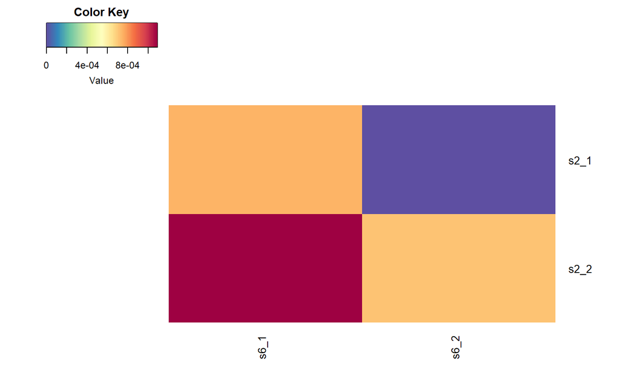

```r
library(RColorBrewer)
library(gplots)
Colors=rev(brewer.pal(11,"Spectral"))
Colors=colorRampPalette(Colors)(100)

table_pct <- tables_p04_p02$overlap_pct
# rename the table for visualization
colnames(table_pct) <- gsub(".tsv", "", colnames(table_pct))
rownames(table_pct) <- gsub(".tsv", "", rownames(table_pct))
# create the heatmap
heatmap.2(as.matrix(table_pct[1:nrow(table_pct)-1, 1:ncol(table_pct)-1]),
          col=Colors, Rowv=FALSE, Colv=FALSE,
          dendrogram='none', trace="none", cexRow=1, cexCol=1, density.info="none")
```

We can see that sample “s2_2” have relatively heavy overlap with the samples of subject “P06”. We can consider to remove sample “s2_2”.

### Cross-cohort overlap

Empirical P values can be calculated for the cross-cohort overlap values using a reference vector. For this example, we will randomly generate a reference vector.

```r
# Randomly generate the reference vector
ref_v <- runif(50000, 0, 0.3)
# extract the prevalence proportion
crosscohort_v <- crosscohort_table[, dim(crosscohort_table)[2]]
# calculate the empirical P values
p_table <- Pcalculator(ref_v, crosscohort_v)
# Here we eliminate row names for presenting since the sequences' names are extremely long.
rownames(p_table) <- NULL
head(p_table)
```

```
#>   value p p_adjust
#> 1   0.6 0        0
#> 2   0.6 0        0
#> 3   0.6 0        0
#> 4   0.6 0        0
#> 5   0.5 0        0
#> 6   0.4 0        0
```

If we set the cutoff value for adjusted P value as 0.05, then we can extract the outliers by

```r
outliers <- p_table[p_table$p_adjust <= 0.05, ]
```